# R für Einsteiger: Musterlösungen

Kapitel 16: Spezielle Regressionsmodelle

*Diese Musterlösung wurde erstellt von Peter Hähner (Ruhr-Universität Bochum).*

*(c) Luhmann: R fÃ¼r Einsteiger, 5. Aufl., Beltz, 2020*

## Vorbereitungen

Setzen Sie ein Arbeitsverzeichnis oder legen Sie ein entsprechendes R-Projekt an (Kap. 23).

Laden Sie dann die Datei `erstis.RData`.

```r
load("erstis.RData")
```

Laden Sie die benötigten Pakete (ggf. müssen Sie diese vorab noch installieren).

```r
library(psych)
library(interactions)
library(emmeans)
```

## Aufgabe 1

Überprüfen Sie regressionsanalytisch, ob sich Personen mit und ohne Kinder (`kinder`) in ihrer Prokrastination (`prok`) unterscheiden. Die Prokrastination ist Ihre abhängige Variable.

```r
# Kodierung der Variable "kinder" prÃ¼fen
contrasts(erstis$kinder)
```

```
##      nein
## ja      0
## nein    1
```

```r
# Modell aufstellen
aufgabe.1 <- lm(prok ~ kinder, data = erstis)
summary(aufgabe.1)
```

```
##
## Call:
## lm(formula = prok ~ kinder, data = erstis)
##
## Residuals:
##      Min       1Q   Median       3Q      Max
## -1.48462 -0.35743  0.04257  0.43577  1.24257
##
## Coefficients:
##             Estimate Std. Error t value Pr(>|t|)
## (Intercept)  2.48462    0.11011  22.566   <2e-16 ***
## kindernein  -0.02718    0.11939  -0.228     0.82
## ---
## Signif. codes:  0 '***' 0.001 '**' 0.01 '*' 0.05 '.' 0.1 ' ' 1
##
## Residual standard error: 0.5614 on 172 degrees of freedom
##   (17 observations deleted due to missingness)
## Multiple R-squared:  0.0003013,  Adjusted R-squared:  -0.005511
## F-statistic: 0.05184 on 1 and 172 DF,  p-value: 0.8202
```

Personen mit Kindern und ohne Kinder unterscheiden sich nicht signifikant in ihrer Prokrastination (*b* = -0.03, *SE* = 0.12, *t*(172) = -0.23, *p* = .820).

## Aufgabe 2

Berechnen Sie den Interaktionseffekt von Gewissenhaftigkeit (`gewiss`) und Neurotizismus (`neuro`) auf die Prokrastination (`prok`). Vergessen Sie nicht, die unabhÃ¤ngigen Variablen zu zentrieren. Stellen Sie die bedingten Regressionsgeraden grafisch dar.

```r
# Variablen zentrieren
erstis$gewiss.c <- as.numeric(scale(erstis$gewiss, scale = FALSE))
erstis$neuro.c <- as.numeric(scale(erstis$neuro, scale = FALSE))

# Modell schÃ¤tzen
aufgabe.2 <- lm(prok ~ gewiss.c * neuro.c, data = erstis)
summary(aufgabe.2)
```

```
##
## Call:
## lm(formula = prok ~ gewiss.c * neuro.c, data = erstis)
##
## Residuals:
##      Min       1Q   Median       3Q      Max
## -1.30617 -0.27484 -0.00424  0.22931  1.35533
##
## Coefficients:
##                  Estimate Std. Error t value Pr(>|t|)
## (Intercept)       2.44909    0.03424  71.524  < 2e-16 ***
## gewiss.c         -0.39429    0.04372  -9.018 4.21e-16 ***
## neuro.c           0.22546    0.04727   4.770 3.98e-06 ***
## gewiss.c:neuro.c  0.05861    0.05260   1.114    0.267
## ---
## Signif. codes:  0 '***' 0.001 '**' 0.01 '*' 0.05 '.' 0.1 ' ' 1
##
## Residual standard error: 0.4456 on 168 degrees of freedom
##   (19 observations deleted due to missingness)
## Multiple R-squared:  0.3748, Adjusted R-squared:  0.3636
## F-statistic: 33.57 on 3 and 168 DF,  p-value: < 2.2e-16
```

Es liegt keine signifikante Interaktion zwischen den Variablen `neuro` und `gewiss` vor (*b* = 0.06, *SE* = 0.05, *t*(168) = 1.11, *p* = .267).

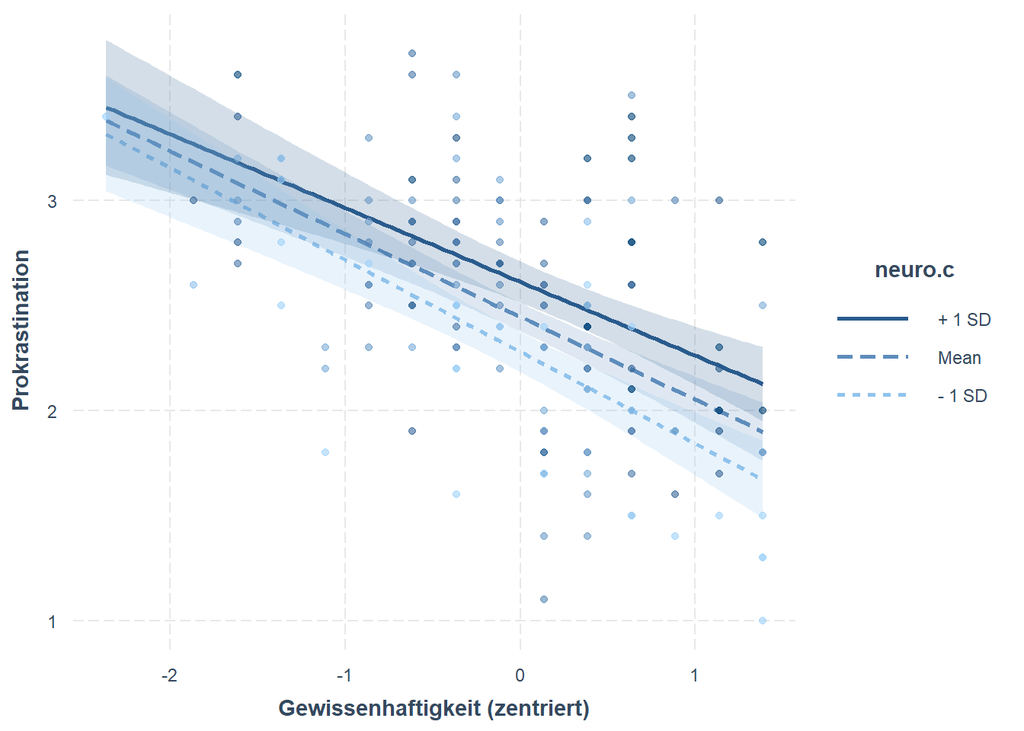

```r
# Bedingte Regressionsgeraden darstellen
interact_plot(aufgabe.2, pred = gewiss.c, modx = neuro.c,
              plot.points = TRUE,
              point.shape = TRUE,
              interval = TRUE,
              x.label = "Gewissenhaftigkeit (zentriert)",
              y.label = "Prokrastination")
```

## Aufgabe 3

Führen Sie eine Kovarianzanalyse durch mit der abhängigen Variablen Prokrastination (`prok`) und den Prädiktoren `kinder` und `gewiss`. Berechnen Sie die adjustierten Mittelwerte für Personen mit und ohne Kinder.

```r
# Modell schÃ¤tzen
aufgabe.3 <- lm(prok ~ gewiss.c + kinder, data = erstis)
summary(aufgabe.3)
```

```
##
## Call:
## lm(formula = prok ~ gewiss.c + kinder, data = erstis)
##
## Residuals:
##      Min       1Q   Median       3Q      Max
## -1.29961 -0.25460 -0.00779  0.24949  1.28403
##
## Coefficients:
##             Estimate Std. Error t value Pr(>|t|)
## (Intercept)  2.52384    0.09462  26.672  < 2e-16 ***
## gewiss.c    -0.36727    0.04663  -7.877 3.99e-13 ***
## kindernein  -0.07442    0.10285  -0.724     0.47
## ---
## Signif. codes:  0 '***' 0.001 '**' 0.01 '*' 0.05 '.' 0.1 ' ' 1
##
## Residual standard error: 0.4818 on 168 degrees of freedom
##   (20 observations deleted due to missingness)
## Multiple R-squared:  0.2698, Adjusted R-squared:  0.2611
## F-statistic: 31.04 on 2 and 168 DF,  p-value: 3.374e-12
```

```r
# Adjustierte Mittelwerte berechnen
emmeans(aufgabe.3, specs = "kinder")
```

```
##  kinder emmean     SE  df lower.CL upper.CL
##  ja       2.53 0.0947 168     2.34     2.72
##  nein     2.46 0.0400 168     2.38     2.54
##
## Confidence level used: 0.95
```

## Aufgabe 4

Überprüfen Sie, ob es einen quadratischen Zusammenhang zwischen der Prokrastination (`prok`; Prädiktor) und der Lebenszufriedenheit (`lz.1`; abhängige Variable) gibt.

```r
# PrÃ¤diktor zentrieren
erstis$prok.c <- as.numeric(scale(erstis$prok, scale = FALSE))

# Modell schÃ¤tzen
aufgabe.4 <- lm(lz.1 ~ prok.c + I(prok.c^2), data = erstis)
summary(aufgabe.4)
```

```
##
## Call:
## lm(formula = lz.1 ~ prok.c + I(prok.c^2), data = erstis)
##
## Residuals:
##      Min       1Q   Median       3Q      Max
## -17.0072  -3.6955   0.9928   3.8492  10.0955
##
## Coefficients:
##             Estimate Std. Error t value Pr(>|t|)
## (Intercept)  25.1696     0.4985  50.490  < 2e-16 ***
## prok.c       -3.7713     0.6948  -5.428 1.93e-07 ***
## I(prok.c^2)  -2.0558     1.0035  -2.049    0.042 *
## ---
## Signif. codes:  0 '***' 0.001 '**' 0.01 '*' 0.05 '.' 0.1 ' ' 1
##
## Residual standard error: 5.094 on 171 degrees of freedom
##   (17 observations deleted due to missingness)
## Multiple R-squared:  0.1549, Adjusted R-squared:  0.145
## F-statistic: 15.67 on 2 and 171 DF,  p-value: 5.653e-07
```

Es gibt einen signifikanten quadratischen Effekt von Prokrastination auf Lebenszufriedenheit (*b* = -2.06, *SE* = 1.00, *t*(171) = -2.05, *p* = .042).

## Aufgabe 5

Versuchen Sie mit einer logistischen Regression vorherzusagen, welche Personen einen Nebenjob (`job`; abhängige Variable haben). Prüfen Sie die folgenden Variablen als Prädiktoren: `kinder`, `gewiss`, `lz.1`.

```r
# Modell schÃ¤tzen
aufgabe.5 <- glm(job ~ kinder + gewiss + lz.1, family = binomial, data = erstis)
summary(aufgabe.5)
```

```
##
## Call:
## glm(formula = job ~ kinder + gewiss + lz.1, family = binomial,
##     data = erstis)
##
## Deviance Residuals:
##     Min       1Q   Median       3Q      Max
## -1.3817  -1.1641  -0.9798   1.1917   1.4240
##
## Coefficients:
##             Estimate Std. Error z value Pr(>|z|)
## (Intercept)  0.05327    0.99969   0.053    0.958
## kindernein  -0.39541    0.43280  -0.914    0.361
## gewiss      -0.10789    0.20111  -0.536    0.592
## lz.1         0.02638    0.02923   0.903    0.367
##
## (Dispersion parameter for binomial family taken to be 1)
##
##     Null deviance: 235.65  on 169  degrees of freedom
## Residual deviance: 233.86  on 166  degrees of freedom
##   (21 observations deleted due to missingness)
## AIC: 241.86
##
## Number of Fisher Scoring iterations: 4
```

```r
# Odds Ratio berechnen
exp(coef(aufgabe.5))
```

```
## (Intercept)  kindernein      gewiss        lz.1
##   1.0547130   0.6734040   0.8977279   1.0267360
```

Keiner der Prädiktoren `kinder`, `gewiss` und `lz.1` trägt signifikant zur Vorhersage bei, ob jemand einen Nebenjob hat oder nicht.